# AIROYoung Exercise Solved

Let's use the classes we **exposed in C++**! Data input in complex application can be a real pain, but still our algorithms need much efficiency. We keep as many as possible components of our software outside the C++ nasty world, let's see **how easily Python can deal** with this tasks!

```python
import networkx as nx
from scipy.spatial.distance import cdist
import numpy as np
from itertools import product
import matplotlib.pyplot as plt
import codecs
import datetime as dt
from ast import literal_eval as make_tuple
```

the following packages are the one we are going to use to read input data from different sources

```python
import ConfigParser as cp
import json
import csv
import xml.etree.ElementTree as xml
import pandas as pd
```

here we import our own files and packages

```python
import Exercise_Solved.AYT_exercise as AYT
import utils.misc as ut
```

## CONFIG

In a *config.ini* we find the date we are considering in our exercise

```python
conf_parser = cp.RawConfigParser()
```

read the value the file and assign it to an object of type *AYT.date*

```python
conf_parser.read('Exercise_Solved/data/config.ini');
date = ut.stringToDate(conf_parser.get('initialize', 'date'))
date = AYT.date(date.year, date.month, date.day)
```

```python
print date, type(date)
```

```
2019-Mar-29 <class 'Exercise_Solved.AYT_exercise.date'>
```

## XML

We want to create a list of recipes, the ingredients are contained in an xml file

```python
recipes = []
```

```python
xml_tree = xml.parse('Exercise_Solved/data/ingredients.xml').getroot()
input_recipes = xml_tree.findall('recipe')
```

make use of the following dictionaries to get the AYT enum value from the string read in the xml file

```python
cook_type_dict = {'oven' : AYT.CookingType.Oven, 'pot' : AYT.CookingType.Pot, 'pan' : AYT.CookingType.Pan}
conserv_dict = {'anywhere' : AYT.Conservation.Anywhere, 'fridge' : AYT.Conservation.Fridge, 'refrigerator' : AYT.Conservation.Refrigerator}
```

use an utility function available to read the ingredients of the recipe

```python
for recipe in input_recipes:
    r = AYT.Recipe(recipe.get('name'))
    r.cooking = cook_type_dict[ut.getXMLelem(recipe, 'cooking_type')]
    r.butter_g = float(ut.getXMLelem(recipe, 'butter'))
    r.chocolate_g = float(ut.getXMLelem(recipe, 'chocolate'))
    r.conservation = conserv_dict[ut.getXMLelem(recipe, 'conservation')]
    r.cooking_duration = AYT.time_duration(0, int(ut.getXMLelem(recipe, 'cooking_duration')),0)
    r.milk_ml = float(ut.getXMLelem(recipe, 'milk'))
    r.eggs = int(ut.getXMLelem(recipe, 'eggs'))
    r.flour_g = float(ut.getXMLelem(recipe, 'flour'))
    recipes.append(r)
```

```python
for r in recipes:
    print r
```

```
recipe_1
recipe_2
recipe_3
recipe_4
recipe_5
recipe_6
```

check how many common ingredients there are between the first two recipes

```python
AYT.Recipe.numCommonIngredients(recipes[0], recipes[1])
```

```
3
```

does the first recipe takes longer to cook than the second one?

```python
recipes[0].cooksSlowerThan(recipes[1])
```

```
False
```

## XLS

In an Excel file we can find all data corresponding to the employees (cooks and waiters)

```python
cooks, waiters, employees = [], [], []
```

read the employee file Excel with Pandas functions

```python
df_empl = pd.read_excel('Exercise_Solved/data/employees.xlsx')
```

```python
df_empl
```

|  | Name | Role | Time per Day |
| --- | --- | --- | --- |
| 0 | tommy | cook | 8 |
| 1 | anna | waiter | 6 |
| 2 | marty | waiter | 4 |
| 3 | lavi | cook | 6 |
| 4 | gasta | NaN | 1 |
| 5 | rosario | cook | 7 |
| 6 | veronica | waiter | 5 |

drop who does not have a role, so he will not work **;p**

```python
df_empl.dropna(inplace=True)
```

create employees by iterating on dataframe rows

```python
for idx, data in df_empl.iterrows():
    if data.Role == 'cook':
        c = AYT.Cook.create(str(data.Name))
        c.time_per_day = AYT.time_duration(data['Time per Day'], 0, 0)
        cooks.append(c)
    else:
        w = AYT.Waiter.create(str(data.Name))
        w.time_per_day = AYT.time_duration(data['Time per Day'], 0, 0)
        waiters.append(w)
```

```python
employees = cooks + waiters
```

```python
for e in employees:
    print 'My name is {}, and {} Today I work {} hours'.format(e.name, e.whatDoIDo(), e.time_per_day)
```

```
My name is tommy, and I am a cook! Today I work 08:00:00 hours
My name is lavi, and I am a cook! Today I work 06:00:00 hours
My name is rosario, and I am a cook! Today I work 07:00:00 hours
My name is anna, and I am a Waiter! Today I work 06:00:00 hours
My name is marty, and I am a Waiter! Today I work 04:00:00 hours
My name is veronica, and I am a Waiter! Today I work 05:00:00 hours
```

## CSV

now we want to assign to each cook the recipes he knows. They are stored in a csv file

```python
recipes_cooks = []
```

read data with csv package

```python
with codecs.open('Exercise_Solved/data/recipes_of_cooks.csv', 'rb', 'utf-16') as f:
    reader = csv.reader(f)
    for row in reader:
        recipes_cooks.append(row)
```

*Hint*: you might have encoding issues...try `codecs.open(filename, 'rb', 'utf-16')` and you're good to go!

```python
recipes_cooks
```

```
[['Cook',
  'Recipe_1',
  'Recipe_2',
  'Recipe_3',
  'Recipe_4',
  'Recipe_5',
  'Recipe_6'],
 ['tommy', '1', '0', '1', '1', '0', '0'],
 ['rosario', '0', '1', '1', '0', '1', '1'],
 ['lavi', '0', '1', '0', '1', '0', '1']]
```

read the same csv file with pandas and make *Cook* as the index column

```python
recipes_cooks = pd.read_csv(codecs.open('Exercise_Solved/data/recipes_of_cooks.csv', 'rb', 'utf-16'), index_col=['Cook'])
```

```python
recipes_cooks
```

| Cook | Recipe_1 | Recipe_2 | Recipe_3 | Recipe_4 | Recipe_5 | Recipe_6 |
| --- | --- | --- | --- | --- | --- | --- |
| tommy | 1 | 0 | 1 | 1 | 0 | 0 |
| rosario | 0 | 1 | 1 | 0 | 1 | 1 |
| lavi | 0 | 1 | 0 | 1 | 0 | 1 |

compute for each cook how many recipes he/she knows (use apply function of dataframe)

```python
recipes_cooks.apply(sum, axis=1)
```

```
Cook
tommy      3
rosario    4
lavi       3
dtype: int64
```

compute for each recipe how many cooks know it (use apply function of dataframe)

```python
recipes_cooks.apply(sum, axis=0)
```

```
Recipe_1    1
Recipe_2    2
Recipe_3    2
Recipe_4    2
Recipe_5    1
Recipe_6    2
dtype: int64
```

assign to each cook in employees the recipes he knows (use *next* to search by condition). `'recipe_{}'.format()` can be useful to find the recipe by its name

```python
for name, recipes_data in recipes_cooks.iterrows():
    cook = next(c for c in employees if c.name == name)
    known_recipes = recipes_data.tolist()
    for i in range(len(known_recipes)):
        if known_recipes[i] == 1:
            r = next(rec for rec in recipes if rec.name == 'recipe_{}'.format(i+1))
            cook.known_recipes.append(r)
```

create the list of *cooks* by removing the waiters from the employees

```python
cooks2 = list(set(employees) - set(waiters))
```

for the next task you may find useful *join()* and *map* python functions

```python
for c in cooks2:
    print '{} can cook: {}'.format(c.name, ','.join(map(str, c.known_recipes)))
```

```
rosario can cook: recipe_2,recipe_3,recipe_5,recipe_6
lavi can cook: recipe_2,recipe_4,recipe_6
tommy can cook: recipe_1,recipe_3,recipe_4
```

## JSON

We want to collect data about some restaurants in Padova area (the best I know!). They are stored in a json file. Besides the restaurants, we want to save also a list of coordinates for each restaurant that will represent a graph

```python
restaurants = []
graph = []
```

```python
input_json = json.load(open('Exercise_Solved/data/restaurants.json'))
```

create restaurants and coordinates, for the latter you may take advantage of the `make_tuple()` python function

```python
for k, v in input_json['restaurants'].iteritems():
    R = AYT.Restaurant(str(k))
    o_time = dt.datetime.strptime(v['open'], '%H:%M')
    c_time = dt.datetime.strptime(v['close'], '%H:%M')
    opening = AYT.time(date, AYT.time_duration(o_time.hour, o_time.minute, 0))
    closing = AYT.time(date, AYT.time_duration(c_time.hour, c_time.minute, 0))
    R.opening_period = AYT.time_period(opening, closing)
    restaurants.append(R)
    coord = make_tuple(v['position'])
    graph.append(coord)
```

```python
for R in restaurants:
    print R.name
```

```
Da Bepi ae scoe
Dalla Ofelia
Il Falco d'Oro
Rosso Pomodoro
Kopfler
La Rosa dei Venti
```

Assign employees to restaurants and viceversa

```python
for i in range(len(cooks)):
    cooks[i].restaurant = restaurants[i]
    waiters[i].restaurant = restaurants[i]
    restaurants[i].employees.append(cooks[i])
    restaurants[i].employees.append(waiters[i])
```

```python
for i in range(len(cooks)):
    print cooks[i].name, 'works', cooks[i].restaurant.name
    print waiters[i].name, 'works', waiters[i].restaurant.name
```

```
tommy works Da Bepi ae scoe
anna works Da Bepi ae scoe
lavi works Dalla Ofelia
marty works Dalla Ofelia
rosario works Il Falco d'Oro
veronica works Il Falco d'Oro
```

let's see our graph (it is a grid)

```python
graph.sort()
```

```python
graph
```

```
[(0, 0), (0, 1), (0, 2), (1, 0), (1, 1), (1, 2)]
```

## Customers

Customers arrive according to a Poisson Process of rate 30. We consider the first 10 clients arriving from 12:00 at the first restaurant

```python
arrival_times = map( lambda x: AYT.time(date, AYT.time_duration(12,x,0)), np.cumsum(np.random.poisson(30, 10)))
```

```python
for a in arrival_times:
    print a
```

```
2019-Mar-29 12:23:00
2019-Mar-29 12:55:00
2019-Mar-29 13:28:00
2019-Mar-29 13:57:00
2019-Mar-29 14:22:00
2019-Mar-29 14:49:00
2019-Mar-29 15:15:00
2019-Mar-29 15:53:00
2019-Mar-29 16:17:00
2019-Mar-29 16:42:00
```

create the last customer arriving at the restaurant, let's say he wants to eat the first recipe

```python
c = AYT.Customer()
c.arrival_time = arrival_times[-1]
c.desired_meal = recipes[0]
```

check if there is at least one cook at the restaurant when the customer gets in that can cook that recipe

```python
cooks_first_restaurants = [ck for ck in cooks if ck.restaurant.name == restaurants[0].name]
cooks_available = [ck for ck in cooks_first_restaurants if restaurants[0].opening_period.begin() + ck.time_per_day > c.arrival_time]
```

```python
cooks_for_recipe = [ck for ck in cooks_available if c.desired_meal in ck.known_recipes]
```

```python
for ck in cooks_for_recipe:
    print 'customer arrives at {}. He wants {}. Cook {} works till {} and can cook {}'.format(c.arrival_time.timeOfDay(),
                                                                           c.desired_meal,
                                                                           ck.name,
                                                                           (ck.restaurant.opening_period.begin() + ck.time_per_day).timeOfDay(),
                                                                           ','.join(map(str,ck.known_recipes)))
```

```
customer arrives at 16:42:00. He wants recipe_1. Cook tommy works till 20:00:00 and can cook recipe_1,recipe_3,recipe_4
```

## TSP

Anna is a very glutton girl, and wants to eat at every restaurant we have! Let's say they all keep open for Anna (or else she would freak out). Anna is also a very lazy girl, and she does not want to do much effort walking through the city, so let's suggest her a short tour by solving a **Traveling Salesman Problem** on our grid graph!

cast the graph to a special Python type, optimized for matrix computations

```python
grid = np.asarray(graph)
```

some python magic for creating a distance matrix computed with *Manhattan distance*

```python
M = np.asmatrix(cdist(grid,grid, 'cityblock'))
```

```python
print M
```

```
[[0. 1. 2. 1. 2. 3.]
 [1. 0. 1. 2. 1. 2.]
 [2. 1. 0. 3. 2. 1.]
 [1. 2. 3. 0. 1. 2.]
 [2. 1. 2. 1. 0. 1.]
 [3. 2. 1. 2. 1. 0.]]
```

create an instance of our network class

```python
network = AYT.Network(len(grid))
```

```python
for i in range(len(network)):
    network[i] = restaurants[i]
```

```python
for i,j in product(range(len(network)),range(len(network))):
    if i != j:
        t = AYT.Trip(M[i,j], AYT.time_duration(0, int(M[i,j]), 0))
        network.pushArc(i,j,t)
```

create an instance of *Networkx* graph class

```python
G = nx.from_numpy_matrix(M)
```

let's solve the problem with our C++ function!

```python
route = AYT.TSP(network)
```

```python
route
```

```
[0, 1, 2, 4, 5, 3, 0]
```

compute the length of the path

```python
sum(M[route[i],route[i+1]] for i in range(len(route)-1))
```

```
8.0
```

build a list of the arcs of the route, that is each pair of consecutive nodes

```python
route_edges = zip(route[:-1], route[1:])
```

```python
route_edges
```

```
[(0, 1), (1, 2), (2, 4), (4, 5), (5, 3), (3, 0)]
```

finally, let's plot the solution found

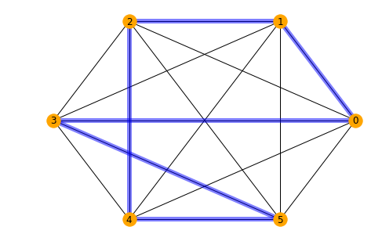

```python
pos = nx.circular_layout(G)  # positions for all nodes

nx.draw(G, pos, node_color='orange', with_labels=True)

nx.draw_networkx_edges(G, pos, edgelist=route_edges, width=6, alpha=0.5, edge_color='b')

plt.show()
```